# STAT 420: Homework 09

Haofei Xu, haofeix2

## Exercise 1 (Writing Functions)

**(a)** Write a function that takes as input a model object (variable) fit via `lm()` and outputs a fitted versus residuals plot. Also, create arguments `pointcol` and `linecol`, which control the point and line colors, respectively. Code the plot to add a horizontal line at $y = 0$, and label the $x$-axis “Fitted” and the $y$-axis “Residuals”.

```r
fitted_vs_resid = function(model, pointcol = "blue", linecol = "orange") {
  plot(fitted(model), resid(model),
       col = pointcol,
       pch = 20,
       cex = 1,
       xlab = "Fitted",
       ylab = "Residuals")
  abline(h = 0, col = linecol, lwd = 2)
}
```

**(b)** Write a function that takes as input a model fit via `lm()` and plots a Normal Q-Q plot of the residuals. Also, create arguments `pointcol` and `linecol`, which control the point and line colors, respectively. Code the plot to add the line from `qqline()`.

```r
Q_Q_plot = function(model, pointcol = "blue", linecol = "orange") {
  qqnorm(resid(model),
       col = pointcol,
       pch = 20,
       cex = 1)
  qqline(resid(model),
         col = linecol,
         lwd = 2)
}
```

**(c)** Test your two functions above on the `test_fit` model. For both functions, specify point and line colors that are not black.

```r
set.seed(114)
test_data = data.frame(x = runif(n = 20, min = 0, max = 10),
                       y = rep(x = 0, times = 20))
test_data$y = with(test_data, 5 + 2 * x + rnorm(n = 20))
test_fit = lm(y ~ x, data = test_data)
```

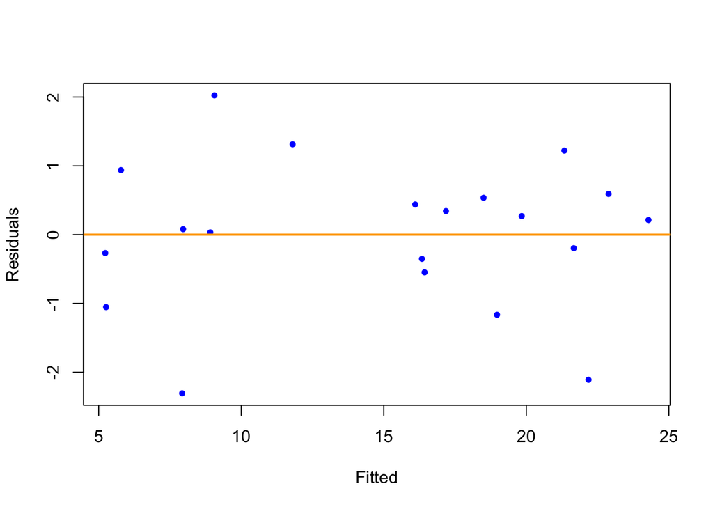

```r
fitted_vs_resid(test_fit)
```

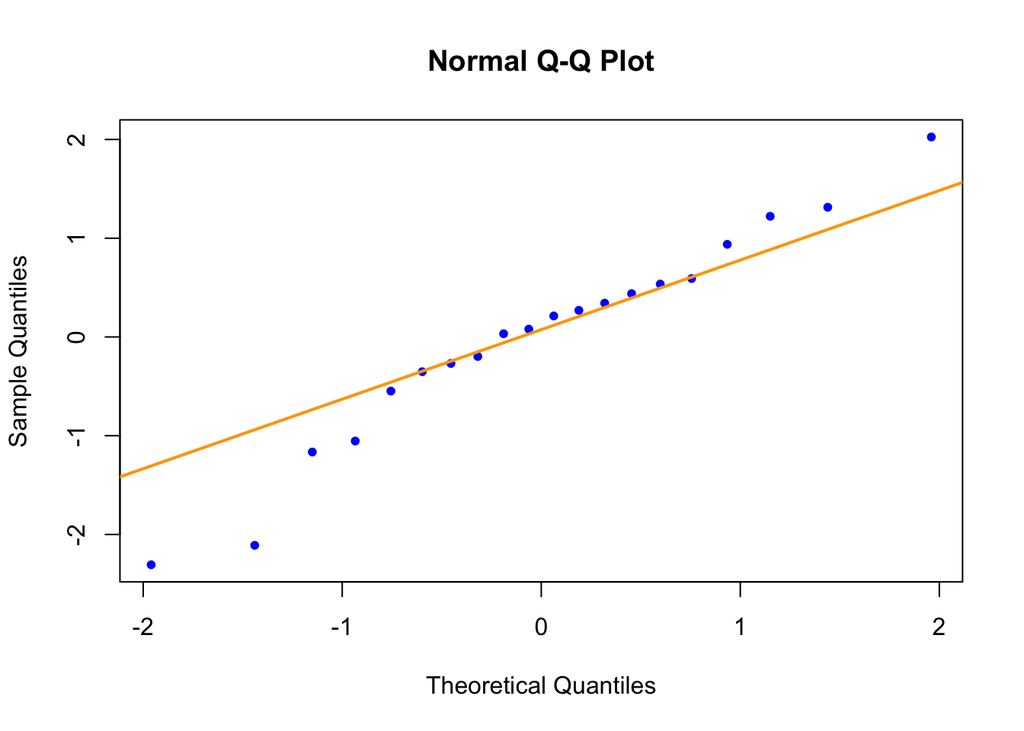

```r
Q_Q_plot(test_fit)
```

## Exercise 2 (Swiss Fertility Data)

For this exercise we will use the `swiss` data, which can be found in the `faraway` package. After loading the `faraway` package, use `?swiss` to learn about this dataset.

```r
library(faraway)
```

**(a)** Fit an additive multiple regression model with `Fertility` as the response and the remaining variables in the `swiss` dataset as predictors. Output the estimated regression coefficients for this model.

```r
model = lm(Fertility ~ ., data = swiss)
coef(model)
```

```
##      (Intercept)      Agriculture      Examination        Education
##          66.9152          -0.1721          -0.2580          -0.8709
##         Catholic Infant.Mortality
##           0.1041           1.0770
```

**(b)** Check the constant variance assumption for this model. Do you feel it has been violated? Justify your answer.

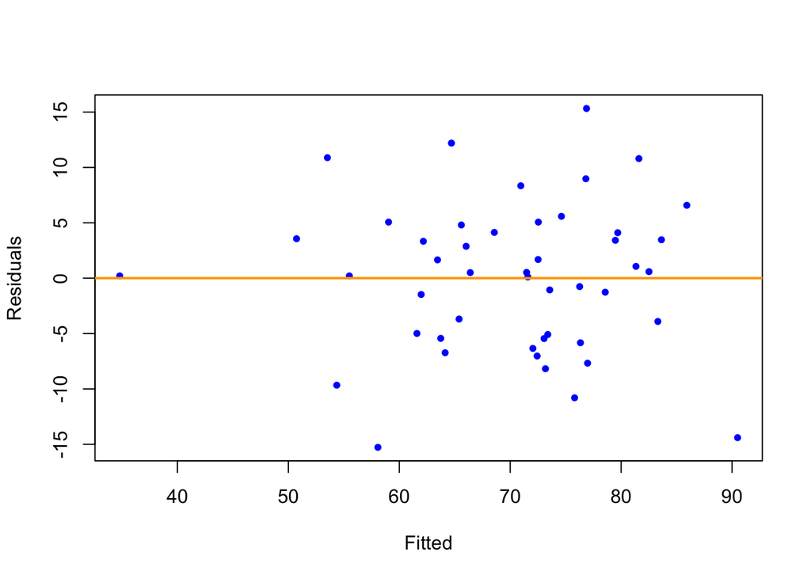

```r
fitted_vs_resid(model)
```

```r
library(lmtest)
bptest(model)
```

```
##
##  studentized Breusch-Pagan test
##
## data:  model
## BP = 5.9, df = 5, p-value = 0.3
```

For the swiss model, p value = 0.3, which is super large. So that we cannot reject the null hypothesis and tend to believe that the constant varianceassumption has not been violated.

**(c)** Check the normality assumption for this model. Do you feel it has been violated? Justify your answer.

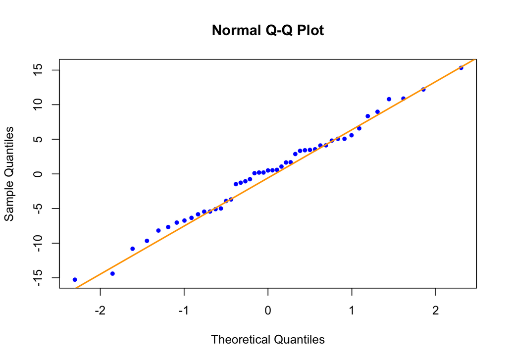

```r
Q_Q_plot(model)
```

```r
shapiro.test(resid(model))
```

```
##
##  Shapiro-Wilk normality test
##
## data:  resid(model)
## W = 0.99, p-value = 0.9
```

The points are tightly around the line and p-value = 0.9 which is not significant to reject the null. I think think is has not been violated.

**(d)** Check for any high leverage observations. Report any observations you determine to have high leverage.

```r
leverage = hatvalues(model)
leverage_mean = mean(leverage)
leverage[leverage > 2 * leverage_mean]
```

```
##    La Vallee V. De Geneve
##       0.3512       0.4558
```

La Vallee V. and DeGeneve have high leverage.

**(e)** Check for any influential observations. Report any observations you determine to be influential.

```r
cooks = cooks.distance(model)
cooks[cooks > 4 / length(cooks)]
```

```
##  Porrentruy      Sierre   Neuchatel Rive Droite Rive Gauche
##      0.2077      0.1476      0.1249      0.1025      0.1124
```

Porrentruy, Sierre, Neuchatel, Rive Droite, and Rive Gauche (all) are influential.

**(f)** Refit the additive multiple regression model without any points you identified as influential. Compare the coefficients of this fitted model to the previously fitted model.

```r
swiss_data = swiss[cooks <= 4 / length(cooks), ]
swiss_data
```

```
##              Fertility Agriculture Examination Education Catholic
## Courtelary        80.2        17.0          15        12     9.96
## Delemont          83.1        45.1           6         9    84.84
## Franches-Mnt      92.5        39.7           5         5    93.40
## Moutier           85.8        36.5          12         7    33.77
## Neuveville        76.9        43.5          17        15     5.16
## Broye             83.8        70.2          16         7    92.85
## Glane             92.4        67.8          14         8    97.16
## Gruyere           82.4        53.3          12         7    97.67
## Sarine            82.9        45.2          16        13    91.38
## Veveyse           87.1        64.5          14         6    98.61
## Aigle             64.1        62.0          21        12     8.52
## Aubonne           66.9        67.5          14         7     2.27
## Avenches          68.9        60.7          19        12     4.43
## Cossonay          61.7        69.3          22         5     2.82
## Echallens         68.3        72.6          18         2    24.20
## Grandson          71.7        34.0          17         8     3.30
## Lausanne          55.7        19.4          26        28    12.11
## La Vallee         54.3        15.2          31        20     2.15
## Lavaux            65.1        73.0          19         9     2.84
## Morges            65.5        59.8          22        10     5.23
## Moudon            65.0        55.1          14         3     4.52
## Nyone             56.6        50.9          22        12    15.14
## Orbe              57.4        54.1          20         6     4.20
## Oron              72.5        71.2          12         1     2.40
## Payerne           74.2        58.1          14         8     5.23
## Paysd'enhaut      72.0        63.5           6         3     2.56
## Rolle             60.5        60.8          16        10     7.72
## Vevey             58.3        26.8          25        19    18.46
## Yverdon           65.4        49.5          15         8     6.10
## Conthey           75.5        85.9           3         2    99.71
## Entremont         69.3        84.9           7         6    99.68
## Herens            77.3        89.7           5         2   100.00
## Martigwy          70.5        78.2          12         6    98.96
## Monthey           79.4        64.9           7         3    98.22
## St Maurice        65.0        75.9           9         9    99.06
## Sion              79.3        63.1          13        13    96.83
## Boudry            70.4        38.4          26        12     5.62
## La Chauxdfnd      65.7         7.7          29        11    13.79
## Le Locle          72.7        16.7          22        13    11.22
```

[output cut: 31 more lines]

```
## Vevey                    20.9
## Yverdon                  22.5
## Conthey                  15.1
## Entremont                19.8
## Herens                   18.3
## Martigwy                 19.4
## Monthey                  20.2
## St Maurice               17.8
## Sion                     18.1
## Boudry                   20.3
## La Chauxdfnd             20.5
## Le Locle                 18.9
## Val de Ruz               20.0
## ValdeTravers             19.5
## V. De Geneve             18.0
```

```r
add_model = lm(Fertility ~ ., data = swiss_data)
coef(add_model) - coef(model)
```

```
##      (Intercept)      Agriculture      Examination        Education
##        -0.470597        -0.046084        -0.242156         0.180475
##         Catholic Infant.Mortality
##        -0.005647         0.280624
```

We found that all coefficients except for `Education` and `Infant.Mortality` are overestimated before.

**(g)** Create a data frame that stores the observations that were “removed” because they were influential. Use the two models you have fit to make predictions with these observations. Comment on the difference between these two sets of predictions.

```r
no_swiss = swiss[cooks > 4 / length(cooks), ]
predict(model, no_swiss)
```

```
##  Porrentruy      Sierre   Neuchatel Rive Droite Rive Gauche
##       90.50       76.88       53.52       54.36       58.07
```

```r
predict(add_model, no_swiss)
```

```
##  Porrentruy      Sierre   Neuchatel Rive Droite Rive Gauche
##       94.44       76.34       55.90       57.93       61.32
```

The relative difference is pretty small compared to the value itself.

## Exercise 3 (Concrete, Again)

Return to the concrete data from the ANOVA homework. Recall, we chose the additive model. Now that we see how ANOVA can be framed as a linear model, check for any violation of assumptions for this model.

```r
concrete = read.csv("concrete.csv")
model = lm(strength ~ ., data = concrete)
bptest(model)
```

```
##
##  studentized Breusch-Pagan test
##
## data:  model
## BP = 3.5, df = 4, p-value = 0.5
```

p-value = 0.5, we do not reject the null hypothesis of constant variance.

```r
shapiro.test(resid(model))
```

```
##
##  Shapiro-Wilk normality test
##
## data:  resid(model)
## W = 0.98, p-value = 0.8
```

p-value = 0.8, we do not reject the null hypothesis of a normal distribution.

```r
leverage = hatvalues(model)
leverage_mean = mean(leverage)
leverage[leverage > 2 * leverage_mean] # No high leverage observation present
```

```
## named numeric(0)
```

```r
cooks = cooks.distance(model)
cooks[cooks > 4 / length(cooks)] # one influential point present
```

```
##     20
## 0.1625
```

```r
new_data = concrete[cooks <= 4 / length(cooks), ]
new_data
```

```
##    curing cement strength
## 1       1      A       14
## 2       1      A       14
## 3       1      A       10
## 4       1      B        6
## 5       1      B        9
## 6       1      B        7
## 7       1      C       22
## 8       1      C       25
## 9       1      C       20
## 10      1      D       10
## 11      1      D       11
## 12      1      D       13
## 13      2      A       15
## 14      2      A       12
```

[output cut: 21 more lines]

```r
new_model = lm(strength ~ ., data = new_data)
coef(new_model) - coef(model)
```

```
## (Intercept)      curing     cementB     cementC     cementD
##  -2.132e-14   2.220e-15   7.105e-15   6.528e-01   9.770e-15
```

Only minor changes here. So our linear model in last hw is good enough to model the data.

## Exercise 4 (Why Bother?)

**Why** do we care about violations of assumptions? One key reason is that the distributions of the parameters that we have used are all reliant on these assumptions. When the assumptions are violated, the distributional results are not correct, so our tests are garbage. **Garbage In, Garbage Out!**

Consider the following setup that we will use for the remainder of the exercise. We choose a sample size of 50.

```r
n = 50
set.seed(1)
x_1 = runif(n, 0, 10)
x_2 = runif(n, -5, 5)
```

Consider the model,

$$Y = 2 + 1 x_1 + 0 x_2 + \epsilon.$$

That is,

- $\beta_0$ = 2
- $\beta_1$ = 1
- $\beta_2$ = 0

We now simulate `y_1` in a manner that does not violate any assumptions, which we will verify. In this case $\epsilon \sim N(0, 1).$

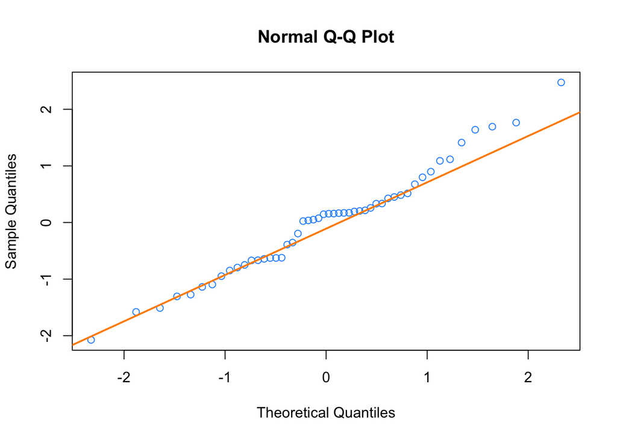

```r
y_1 = 2 + x_1 + 0 * x_2 + rnorm(n = n, mean = 0, sd = 1)
fit_1 = lm(y_1 ~ x_1 + x_2)
qqnorm(resid(fit_1), col = "dodgerblue")
qqline(resid(fit_1), col = "darkorange", lwd = 2)
```

```r
shapiro.test(resid(fit_1))
```

```
##
##  Shapiro-Wilk normality test
##
## data:  resid(fit_1)
## W = 0.98, p-value = 0.6
```

Then, we simulate `y_2` in a manner that **does** violate assumptions, which we again verify. In this case $\epsilon \sim N(0, \sigma = |x_2|).$

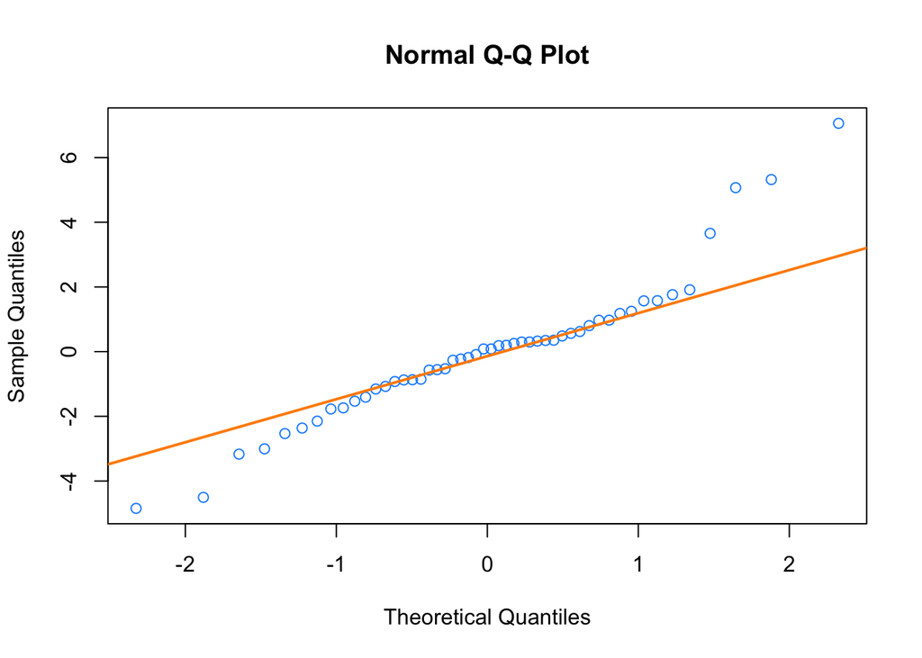

```r
y_2 = 2 + x_1 + 0 * x_2 + rnorm(n = n, mean = 0, sd = abs(x_2))
fit_2 = lm(y_2 ~ x_1 + x_2)
qqnorm(resid(fit_2), col = "dodgerblue")
qqline(resid(fit_2), col = "darkorange", lwd = 2)
```

```r
shapiro.test(resid(fit_2))
```

```
##
##  Shapiro-Wilk normality test
##
## data:  resid(fit_2)
## W = 0.93, p-value = 0.005
```

**(a)** Use the following code after changing `birthday` to your birthday.

```r
num_sims = 1000
p_val_1 = rep(0, num_sims)
p_val_2 = rep(0, num_sims)
birthday = 20000623
set.seed(birthday)
```

Repeat the above process of generating `y_1` and `y_2` as defined above, and fit models with each as the response `1000` times. Each time, store the p-value for testing,

$$\beta_2 = 0,$$

using both models, in the appropriate variables defined above. (You do not need to use a data frame as we have in the past. Although, feel free to modify the code to instead use a data frame.)

```r
for(i in 1:num_sims) {
  y_1        = 2 + x_1 + 0 * x_2 + rnorm(n)
  y_2        = 2 + x_1 + 0 * x_2 + rnorm(n, 0, abs(x_2))
  fit_1      = lm(y_1 ~ x_1 + x_2)
  fit_2      = lm(y_2 ~ x_1 + x_2)
  p_val_1[i] = summary(fit_1)$coef[3,4]
  p_val_2[i] = summary(fit_2)$coef[3,4]
}
```

**(b)** What proportion of the `p_val_1` values are less than 0.05? Less than 0.10? What proportion of the `p_val_2` values are less than 0.05? Less than 0.10? Briefly explain these results.

```r
mean(p_val_1 < 0.05) #proportion of the p_val_1 less than 0.05
```

```
## [1] 0.056
```

```r
mean(p_val_1 < 0.10) #proportion of the p_val_1 less than 0.1
```

```
## [1] 0.11
```

```r
mean(p_val_2 < 0.05) #proportion of the p_val_2 less than 0.05
```

```
## [1] 0.157
```

```r
mean(p_val_2 < 0.10) #proportion of the p_val_2 less than 0.1
```

```
## [1] 0.233
```

We find that the model fitted with data does not violate the assumptions. Only a small percent of them reject the null hypothesis. But for `p_val_2`, it looks like a violation of assumptions.